# Tutorial 2: Predicting Heart Disease Using Instance- and Tree-Based Models

CHEE4003: Special Topics A - Artificial Intelligence in Chemical Engineering

Published

October 8, 2026

# Exploring the Heart Disease Dataset

In this tutorial, we will work with a **Heart Disease Dataset** (sourced from [UCI Machine Learning Repository](https://archive.ics.uci.edu/dataset/45/heart+disease)). The dataset contains clinical and diagnostic information collected from patients undergoing assessment for cardiovascular disease. It provides a realistic example of a healthcare classification problem and is commonly used to demonstrate machine learning techniques for medical decision making.

In this problem, patient demographic information, clinical measurements, and diagnostic indicators are used as input features to predict whether a patient has heart disease. A typical machine learning workflow for this classification task is illustrated in Figure 1.

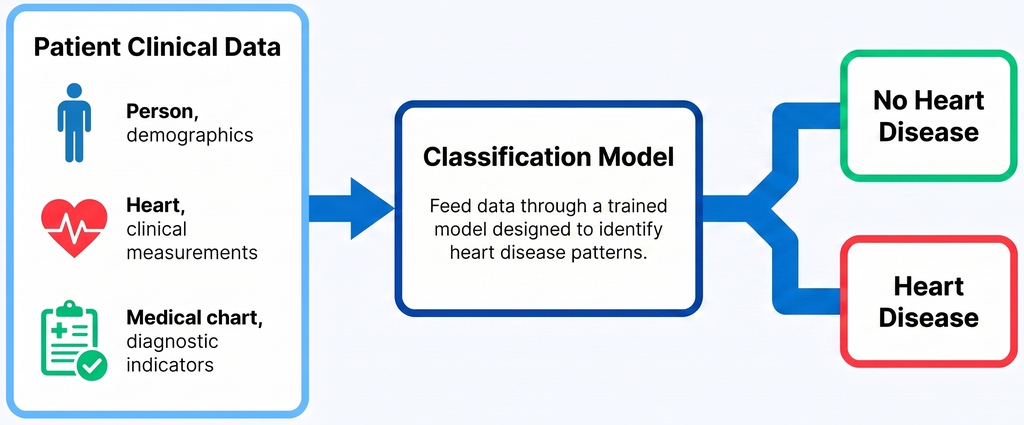

Figure 1: Patient features used to classify the presence or absence of heart disease.

The objective of this dataset is to predict the presence or absence of heart disease based on a range of patient characteristics and clinical measurements. These variables include demographic information such as age and sex, physiological measurements such as resting blood pressure, cholesterol levels, and maximum heart rate, as well as diagnostic indicators obtained from electrocardiogram and exercise stress tests. Together, these features provide information that may be useful for identifying patients at increased risk of cardiovascular disease.

You can download the dataset below:

```
heart.csv
```

```
age,sex,cp,trestbps,chol,fbs,restecg,thalach,exang,oldpeak,slope,ca,thal,num
63,1,1,145,233,1,2,150,0,2.3,3,0,6,0
67,1,4,160,286,0,2,108,1,1.5,2,3,3,2
67,1,4,120,229,0,2,129,1,2.6,2,2,7,1
37,1,3,130,250,0,0,187,0,3.5,3,0,3,0
... (294 more lines)
```

Below is a description of each of the variables in the dataset:

| Feature | Description |
| --- | --- |
| age | age of the patient [years] |
| sex | sex of the patient [1: Male, 0: Female] |
| cp | chest pain type [1: Typical Angina, 2: Atypical Angina, 3: Non-Anginal Pain, 4: Asymptomatic] |
| trestbps | resting blood pressure [mm Hg] |
| chol | serum cholesterol [mg/dl] |
| fbs | fasting blood sugar [1: if fbs > 120 mg/dl, 0: otherwise] |
| restecg | resting electrocardiogram results [0: Normal, 1: having ST-T wave abnormality (T wave inversions and/or ST elevation or depression of > 0.05 mV), 2: showing probable or definite left ventricular hyper… |
| thalach | maximum heart rate achieved |
| exang | exercise-induced angina [1: Yes, 0: No] |
| oldpeak | ST segment depression during exercise relative to rest [higher = greater abnormality, lower = smaller or no abnormality] |
| slope | the slope of the peak exercise ST segment [1: upsloping, 2: flat, 3: downsloping] |
| ca | number of major vessels colored by fluoroscopy [(0, 1, 2, 3)] |
| thal | thalassemia type [3: Normal, 6: Fixed defect, 7: Reversible defect] |
| num | diagnosis of heart disease [(1, 2, 3, 4): presence of heart disease, 0: absence of heart disease] |

# The Classification Problem

From a machine learning perspective, this is a **classification problem**. The target variable, `num`, indicates whether heart disease is present. In the original dataset, values greater than zero indicate the presence of heart disease and higher values represent increasing severity of disease. For many classification applications, this variable can be simplified into a binary outcome representing either the presence or absence of cardiovascular disease.

## Part A: Preparing the Data

Before we can train a machine learning model, we need to prepare the data. This involves loading the dataset, exploring its structure, and performing any necessary preprocessing steps. And before we can even do that, we need to have the correct libraries imported. Copy the following code into your script to import the necessary libraries:

```
import_libraries.py
```

```python
import pandas as pd
import matplotlib.pyplot as plt
import seaborn as sns
from sklearn.model_selection import train_test_split
from sklearn.preprocessing import StandardScaler
from sklearn.neighbors import KNeighborsClassifier
from sklearn.tree import DecisionTreeClassifier
from sklearn.ensemble import RandomForestClassifier
```

### Task 1 : Load the dataset

Write a function `load_data` that loads the dataset and returns two Pandas arrays: `X` containing the features and `y` containing the labels. Additionally, print the shape of `X` and `y` to confirm that the data has been loaded correctly. Additionally, reformat `y` so that it contains only binary values (0 and 1), where 1 indicates the presence of heart disease and 0 indicates its absence. The function description is provided below:

```
load_data.py
```

```python
def load_data(file_path):
    """
    Load the dataset from the specified file path and return the features and labels as NumPy arrays

    Parameters
    ----------
    file_path : str
        The path to the CSV file containing the dataset.

    Returns
    -------
    X : pd.DataFrame
        A Pandas DataFrame containing the features (input variables).
    y : pd.Series
        A Pandas Series containing the labels (output variable).
    """
```

When you run this function, it should yield the following output:

X, y = load_data('data/heart.csv')

Features shape: (297, 13)

Labels shape: (297,)

**Callout-answer**Answer**

```
load_data.py
```

```python
def load_data(file_path):
    """
    Load the dataset from the specified file path and return the features and labels as NumPy arrays

    Parameters
    ----------
    file_path : str
        The path to the CSV file containing the dataset.

    Returns
    -------
    X : pd.DataFrame
        A Pandas DataFrame containing the features (input variables).
    y : pd.Series
        A Pandas Series containing the labels (output variable).
    """

    df = pd.read_csv(file_path)

    X = df.drop('num', axis=1)
    y = df['num']

    y=y.apply(lambda x: 1 if x > 0 else 0)

    print(f"Features shape: {X.shape}")
    print(f"Labels shape: {y.shape}")

    return X, y
X, y = load_data('data/heart.csv')
```

Output

```
Features shape: (297, 13)
Labels shape: (297,)
```

### Task 2 : Explore the dataset

Once the dataset is loaded, we can explore its structure and gain insights into the data. Write a function `explore_data` that starts by displaying the first few rows of the features and labels using `.head()`. Next, use `.describe()` to obtain a statistical summary of the features, including their mean, standard deviation, and range. Finally, use `.value_counts()` to determine the number of patients with and without heart disease.

```
explore_data.py
```

```python
def explore_data(X, y):
    """
    Explore the dataset by printing the first 5 rows, summary statistics, and label distribution.

    Parameters
    ----------
    X : pd.DataFrame
        A Pandas DataFrame containing the features (input variables).
    y : pd.Series
        A Pandas Series containing the labels (output variable).

    Returns
    -------
    None
        Prints the first 5 rows of the dataset, summary statistics for the
        features, and the distribution of the labels.
    """
```

Here is what your function should output:

explore_data(X, y)

First 5 rows of features:

age sex cp trestbps chol fbs restecg thalach exang oldpeak slope \

0 63 1 1 145 233 1 2 150 0 2.3 3

1 67 1 4 160 286 0 2 108 1 1.5 2

2 67 1 4 120 229 0 2 129 1 2.6 2

3 37 1 3 130 250 0 0 187 0 3.5 3

4 41 0 2 130 204 0 2 172 0 1.4 1

ca thal

0 0 6

1 3 3

2 2 7

3 0 3

4 0 3

First 5 rows of labels:

0 0

1 1

2 1

3 0

4 0

Name: num, dtype: int64

Summary statistics of features:

age sex cp trestbps chol fbs \

count 297.000000 297.000000 297.000000 297.000000 297.000000 297.000000

mean 54.542088 0.676768 3.158249 131.693603 247.350168 0.144781

std 9.049736 0.468500 0.964859 17.762806 51.997583 0.352474

min 29.000000 0.000000 1.000000 94.000000 126.000000 0.000000

25% 48.000000 0.000000 3.000000 120.000000 211.000000 0.000000

50% 56.000000 1.000000 3.000000 130.000000 243.000000 0.000000

75% 61.000000 1.000000 4.000000 140.000000 276.000000 0.000000

max 77.000000 1.000000 4.000000 200.000000 564.000000 1.000000

restecg thalach exang oldpeak slope ca \

count 297.000000 297.000000 297.000000 297.000000 297.000000 297.000000

mean 0.996633 149.599327 0.326599 1.055556 1.602694 0.676768

std 0.994914 22.941562 0.469761 1.166123 0.618187 0.938965

min 0.000000 71.000000 0.000000 0.000000 1.000000 0.000000

25% 0.000000 133.000000 0.000000 0.000000 1.000000 0.000000

50% 1.000000 153.000000 0.000000 0.800000 2.000000 0.000000

75% 2.000000 166.000000 1.000000 1.600000 2.000000 1.000000

max 2.000000 202.000000 1.000000 6.200000 3.000000 3.000000

thal

count 297.000000

mean 4.730640

std 1.938629

min 3.000000

25% 3.000000

50% 3.000000

75% 7.000000

max 7.000000

Label distribution:

num

0 160

1 137

Name: count, dtype: int64

**CautionVisualisation of the dataset**

Although the summary statistics provide a good overview of the dataset, visualising the data can help us better understand the relationships between features and labels. In your own time, you should explore the dataset further by creating visualisations such as histograms, box plots, and scatter plots (i.e., the full process done in tutorial 1).

**Callout-answer**Answer**

```
explore_data.py
```

```python
def explore_data(X, y):
    """
    Explore the dataset by printing the first 5 rows, summary statistics, and label distribution.

    Parameters
    ----------
    X : pd.DataFrame
        A Pandas DataFrame containing the features (input variables).
    y : pd.Series
        A Pandas Series containing the labels (output variable).

    Returns
    -------
    None
        Prints the first 5 rows of the dataset, summary statistics for the
        features, and the distribution of the labels.
    """

    print("First 5 rows of features:")
    print(X.head())
    print("First 5 rows of labels:")
    print(y.head())
    print("Summary statistics of features:")
    print(X.describe())
    print("Label distribution:")
    print(y.value_counts())

explore_data(X, y)
```

Output

```
First 5 rows of features:
   age  sex  cp  trestbps  chol  fbs  restecg  thalach  exang  oldpeak  slope  \
0   63    1   1       145   233    1        2      150      0      2.3      3
1   67    1   4       160   286    0        2      108      1      1.5      2
2   67    1   4       120   229    0        2      129      1      2.6      2
3   37    1   3       130   250    0        0      187      0      3.5      3
4   41    0   2       130   204    0        2      172      0      1.4      1

   ca  thal
0   0     6
1   3     3
2   2     7
3   0     3
4   0     3
First 5 rows of labels:
0    0
1    1
2    1
3    0
4    0
Name: num, dtype: int64
Summary statistics of features:
              age         sex          cp    trestbps        chol         fbs  \
count  297.000000  297.000000  297.000000  297.000000  297.000000  297.000000
mean    54.542088    0.676768    3.158249  131.693603  247.350168    0.144781
std      9.049736    0.468500    0.964859   17.762806   51.997583    0.352474
min     29.000000    0.000000    1.000000   94.000000  126.000000    0.000000
25%     48.000000    0.000000    3.000000  120.000000  211.000000    0.000000
50%     56.000000    1.000000    3.000000  130.000000  243.000000    0.000000
75%     61.000000    1.000000    4.000000  140.000000  276.000000    0.000000
max     77.000000    1.000000    4.000000  200.000000  564.000000    1.000000

          restecg     thalach       exang     oldpeak       slope          ca  \
count  297.000000  297.000000  297.000000  297.000000  297.000000  297.000000
mean     0.996633  149.599327    0.326599    1.055556    1.602694    0.676768
std      0.994914   22.941562    0.469761    1.166123    0.618187    0.938965
min      0.000000   71.000000    0.000000    0.000000    1.000000    0.000000
25%      0.000000  133.000000    0.000000    0.000000    1.000000    0.000000
50%      1.000000  153.000000    0.000000    0.800000    2.000000    0.000000
75%      2.000000  166.000000    1.000000    1.600000    2.000000    1.000000
max      2.000000  202.000000    1.000000    6.200000    3.000000    3.000000

             thal
count  297.000000
mean     4.730640
std      1.938629
min      3.000000
25%      3.000000
50%      3.000000
75%      7.000000
max      7.000000
Label distribution:
num
0    160
1    137
Name: count, dtype: int64
```

### Task 3 : Preprocess the dataset

Before training a model on the dataset, we need to preprocess the data. This involves splitting the dataset into **training, validation, and testing sets**.

**NoteWhy do we preprocess?**

Splitting the dataset into training, validation, and testing sets is important to **estimate** a model’s performance on unseen data. A model that performs well on the training data is of little value if it performs poorly on unseen data.

The **training set** is used to fit the model, the **validation set** is used to tune model hyperparameters and compare different models, and the **testing set** is used to evaluate the final model’s ability to generalise to unseen data. This separation helps prevent overfitting and provides a more reliable estimate of real-world performance.

We also often scale features to ensure that all features are treated with equal importance. However, because we are using k-NN and tree-based models, feature scaling is not strictly necessary.

Write a function `preprocess_data` that takes the features and labels as input and splits the dataset into **training, validation, and testing sets** using `train_test_split`. For this tutorial, use a **70% training split**, then split the remaining **30% equally between the validation and testing sets** (15% each). Use a `random_state` of `42` for reproducibility. The function should return the training, validation, and testing features and labels.

```
preprocess_data.py
```

```python
def preprocess_data(X, y, temp_size=0.3, test_size=0.50, random_state=42):
    """
    Preprocess the dataset by splitting into training, validation,
    and testing sets.

    Parameters
    ----------
    X : pd.DataFrame
        A Pandas DataFrame containing the features (input variables).
    y : pd.Series
        A Pandas Series containing the labels (output variable).
    train_size : float, optional
        The proportion of the dataset to include in the training set
        (default is 0.70).
    temp_size : float, optional
        The proportion of the dataset to reserve for validation and
        testing (default is 0.30).
    test_size : float, optional
        The proportion of the temporary data to include in the test set
        (default is 0.50, resulting in a 15% test set and 15% validation set).
    random_state : int, optional
        The random seed for reproducibility (default is 42).

    Returns
    -------
    X_train : pd.DataFrame
        Training features.
    X_val : pd.DataFrame
        Validation features.
    X_test : pd.DataFrame
        Testing features.
    y_train : pd.Series
        Training labels.
    y_val : pd.Series
        Validation labels.
    y_test : pd.Series
        Testing labels.
    """

    return X_train, X_val, X_test, y_train, y_val, y_test
```

The example usage of the function is provided below:

X_train, X_val, X_test, y_train, y_val, y_test = preprocess_data(X, y)

X_train.shape, X_val.shape, X_test.shape, y_train.shape, y_val.shape, y_test.shape

((207, 13), (45, 13), (45, 13), (207,), (45,), (45,))

**Callout-answer**Answer**

```
preprocess_data.py
```

```python
def preprocess_data(X, y, temp_size=0.3, test_size=0.50, random_state=42):
    """
    Preprocess the dataset by splitting into training, validation,
    and testing sets.

    Parameters
    ----------
    X : pd.DataFrame
        A Pandas DataFrame containing the features (input variables).
    y : pd.Series
        A Pandas Series containing the labels (output variable).
    train_size : float, optional
        The proportion of the dataset to include in the training set
        (default is 0.70).
    temp_size : float, optional
        The proportion of the dataset to reserve for validation and
        testing (default is 0.30).
    test_size : float, optional
        The proportion of the temporary data to include in the test set
        (default is 0.50, resulting in a 15% test set and 15% validation set).
    random_state : int, optional
        The random seed for reproducibility (default is 42).

    Returns
    -------
    X_train : pd.DataFrame
        Training features.
    X_val : pd.DataFrame
        Validation features.
    X_test : pd.DataFrame
        Testing features.
    y_train : pd.Series
        Training labels.
    y_val : pd.Series
        Validation labels.
    y_test : pd.Series
        Testing labels.
    """

    # Split the dataset into a training set (70%) and a temporary set (30%)
    X_train, X_temp, y_train, y_temp = train_test_split(X, y, test_size=temp_size,stratify=y, random_state=random_state)

    # Split the temporary set equally into validation (15%) and testing (15%)
    X_val, X_test, y_val, y_test = train_test_split(X_temp, y_temp, test_size=test_size,stratify=y_temp, random_state=random_state)

    return X_train, X_val, X_test, y_train, y_val, y_test

X_train, X_val, X_test, y_train, y_val, y_test = preprocess_data(X, y)
X_train.shape, X_val.shape, X_test.shape, y_train.shape, y_val.shape, y_test.shape
```

Output

```
((207, 13), (45, 13), (45, 13), (207,), (45,), (45,))
```

## Part B: Training and evaluating the Models

**NoteWhat is accuracy?**

Accuracy is the proportion of predictions that a classification model gets correct:

$$\mathrm{Accuracy}
=
\frac{\mathrm{Number\ of\ Correct\ Predictions}}
{\mathrm{Total\ Number\ of\ Predictions}}$$

The value ranges from 0 to 1 (or 0% to 100%).

For example, if a model correctly predicts whether 54 out of 60 patients have heart disease, the accuracy is

$$\mathrm{Accuracy}=\frac{54}{60} = 0.90 = 90\%$$

In this tutorial, we will compare the training accuracy and validation accuracy of different classification models. A model with high validation accuracy generally performs well on unseen data, while a large difference between training and validation accuracy is often a sign of overfitting.

Accuracy provides a simple and intuitive measure of classifier performance, making it useful for comparing models. However, it does not distinguish between different types of prediction errors and can sometimes give a misleading impression of performance, particularly when the classes are imbalanced. A more detailed discussion of classification performance metrics, including **precision**, **recall**, **F1-score**, **false positive (FP) rate**, and **false negative (FN) rate**, will be provided in the next tutorial.

### Task 4 : Train the K-Nearest Neighbours (k-NN) Classifier

Now that the dataset is preprocessed, the k-NN classifier can be trained. Write a function `train_knn_classifier` that takes the training features and labels as input and trains a k-NN classifier using `KNeighborsClassifier` from `sklearn`. It should then evaluate the accuracy of the model on both training and validation sets and return the trained classifier. The function description is provided below:

```
train_knn_classifier.py
```

```python
def train_knn_classifier(X_train, y_train, X_val, y_val, n_neighbors):
    """
    Train a k-NN classifier using the training features and labels.

    Parameters
    ----------
    X_train : pd.DataFrame
        Training features.
    y_train : pd.Series
        Training labels.
    X_val : pd.DataFrame
        Validation features.
    y_val : pd.Series
        Validation labels.
    n_neighbors : int
        The number of neighbors to use for k-NN classification.

    Returns
    -------
    knn_classifier : KNeighborsClassifier
        The trained k-NN classifier.
    accuracy_train : float
        Accuracy of the model on the training set.
    accuracy_val : float
        Accuracy of the model on the validation set.
    """

    return knn_classifier, accuracy_train, accuracy_val
```

The example usage of the function is provided below:

n_neighbors = 5

knn_classifier, accuracy_train, accuracy_val = train_knn_classifier(X_train, y_train, X_val, y_val, n_neighbors)

print(f"Training accuracy of k-NN classifier with {n_neighbors} neighbors: {accuracy_train:.2f}")

Training accuracy of k-NN classifier with 5 neighbors: 0.77

print(f"Validation accuracy of k-NN classifier with {n_neighbors} neighbors: {accuracy_val:.2f}")

Validation accuracy of k-NN classifier with 5 neighbors: 0.60

**NoteTraining accuracy vs validation accuracy**

- **Training accuracy** measures how well a model predicts the data it was trained on.
- **Validation accuracy** measures how well a model predicts previously unseen data.
- A good model should achieve high validation accuracy, not just high training accuracy.
- If training accuracy is much higher than validation accuracy, the model may be overfitting the training data.

**Callout-answer**Answer**

```
train_knn_classifier.py
```

```python
def train_knn_classifier(X_train, y_train, X_val, y_val, n_neighbors):
    """
    Train a k-NN classifier using the training features and labels.

    Parameters
    ----------
    X_train : pd.DataFrame
        Training features.
    y_train : pd.Series
        Training labels.
    X_val : pd.DataFrame
        Validation features.
    y_val : pd.Series
        Validation labels.
    n_neighbors : int
        The number of neighbors to use for k-NN classification.

    Returns
    -------
    knn_classifier : KNeighborsClassifier
        The trained k-NN classifier.
    accuracy_train : float
        Accuracy of the model on the training set.
    accuracy_val : float
        Accuracy of the model on the validation set.
    """

    # Create a k-NN classifier with the specified number of neighbors
    knn_classifier = KNeighborsClassifier(n_neighbors=n_neighbors)

    # Train the k-NN classifier on the training data
    knn_classifier.fit(X_train, y_train)

    # Evaluate the accuracy of the model on the training set
    accuracy_train = knn_classifier.score(X_train, y_train)

    # Evaluate the accuracy of the model on the validation set
    accuracy_val = knn_classifier.score(X_val, y_val)

    return knn_classifier, accuracy_train, accuracy_val

n_neighbors = 5
knn_classifier, accuracy_train, accuracy_val = train_knn_classifier(X_train, y_train, X_val, y_val, n_neighbors)
print(f"Training accuracy of k-NN classifier with {n_neighbors} neighbors: {accuracy_train:.2f}")
print(f"Validation accuracy of k-NN classifier with {n_neighbors} neighbors: {accuracy_val:.2f}")
```

Output

```
Training accuracy of k-NN classifier with 5 neighbors: 0.77
Validation accuracy of k-NN classifier with 5 neighbors: 0.60
```

### Task 5 : Determine the optimal number of neighbors for k-NN

The accuracy of the simple k-NN classifier can be further improved by tuning the hyperparameter `n_neighbors`. Write a function `explore_n_neighbors` that takes the training and validation features and labels as input, and evaluates the accuracy of the k-NN classifier for different values of `n_neighbors` up to `max_neighbors`. The function should show a plot of the accuracy against the number of neighbors.

```
explore_n_neighbors.py
```

```python
def explore_n_neighbors(X_train, y_train, X_val, y_val, max_neighbors):
    """
    Explore the accuracy of the k-NN classifier for different values of n_neighbors.

    Parameters
    ----------
    X_train : pd.DataFrame
        Training features.
    y_train : pd.Series
        Training labels.
    X_val : pd.DataFrame
        Validation features.
    y_val : pd.Series
        Validation labels.
    max_neighbors : int
        The maximum number of neighbors to evaluate.

    Returns
    -------
    None
        Displays a line plot showing the training and validation accuracies
        of the k-NN classifier for values of n_neighbors from 1 to
        max_neighbors.
    """
```

The example usage of the function is provided below along with the output plot:

max_neighbors = 20

explore_n_neighbors(X_train, y_train, X_val, y_val, max_neighbors)

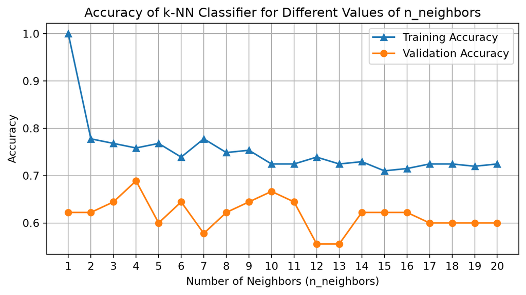

From the plot, what is the optimal value of `n_neighbors` that yields the highest accuracy? Why might this be the case?

**Callout-answer**Answer**

```
explore_n_neighbors.py
```

```python
def explore_n_neighbors(X_train, y_train, X_val, y_val, max_neighbors):
    """
    Explore the accuracy of the k-NN classifier for different values of n_neighbors.

    Parameters
    ----------
    X_train : pd.DataFrame
        Training features.
    y_train : pd.Series
        Training labels.
    X_val : pd.DataFrame
        Validation features.
    y_val : pd.Series
        Validation labels.
    max_neighbors : int
        The maximum number of neighbors to evaluate.

    Returns
    -------
    None
        Displays a line plot showing the training and validation accuracies
        of the k-NN classifier for values of n_neighbors from 1 to
        max_neighbors.
    """
    accuracies_train = []
    accuracies_val = []
    for n in range(1, max_neighbors + 1):
        knn_classifier, accuracy_train, accuracy_val = train_knn_classifier(X_train, y_train, X_val, y_val, n)
        accuracies_train.append(accuracy_train)
        accuracies_val.append(accuracy_val)

    fig, ax = plt.subplots(figsize=(7, 4))
    ax.plot(range(1, max_neighbors + 1), accuracies_train, marker='^',label='Training Accuracy')
    ax.plot(range(1, max_neighbors + 1), accuracies_val, marker='o',label='Validation Accuracy')
    ax.set_title('Accuracy of k-NN Classifier for Different Values of n_neighbors')
    ax.set_xlabel('Number of Neighbors (n_neighbors)')
    ax.set_ylabel('Accuracy')
    ax.set_xticks(range(1, max_neighbors + 1))
    ax.legend(loc='best')
    plt.grid()
    plt.tight_layout()
    plt.show()

max_neighbors = 20
explore_n_neighbors(X_train, y_train, X_val, y_val, max_neighbors)
```

Output

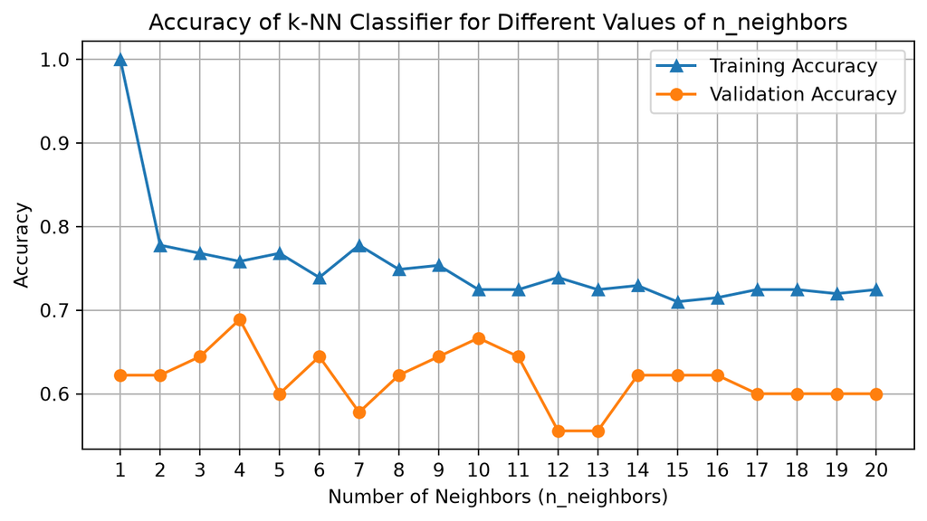

The best value of `n_neighbors` is **4**, as it produces the highest accuracy on the validation set. Small values of `k` can lead to **overfitting**, where the model becomes overly sensitive to individual training observations and captures noise rather than meaningful patterns. In contrast, large values of `k` can lead to **underfitting**, as predictions are influenced by an increasingly broad neighbourhood of data points, causing important local patterns to be smoothed out. A value of `k = 4` provides a good balance between these two extremes, resulting in the highest validation accuracy and making it the preferred choice for the final model.

### Task 6 : Test the K-Nearest Neighbours (k-NN) Classifier

Having selected the optimal value of `n_neighbors` using the validation set, we can now evaluate the final k-NN model on the testing set. Unlike the validation set, which is used for model selection and hyperparameter tuning, the testing set is reserved exclusively for the final assessment of model performance.

**NoteWhy do we use a testing set?**

The testing set provides an **unbiased estimate** of how well the final model is likely to perform on new, unseen data.

- The **training set** is used to fit the model.
- The **validation set** is used to select hyperparameters, such as the value of `k`.
- The **testing set** is used only after all model choices have been made.

Keeping the testing set separate helps ensure that the reported performance is a realistic measure of the model’s ability to generalise beyond the data used during model development.

Using the optimal value of `n_neighbors` identified from the validation set, reuse the `train_knn_classifier` function to train a k-NN classifier on the training data. Then evaluate the classifier on both the training and testing sets. Report the training and testing accuracies, and compare the results to assess whether the model generalises well to unseen data.

```python
# Reuse the train_knn_classifier function with the optimal value of n_neighbors
n_neighbors = n_neighbors_opt
knn_classifier, accuracy_train, accuracy_test = train_knn_classifier(X_train, y_train, X_test, y_test, n_neighbors)
print(f"Training accuracy of k-NN classifier with {n_neighbors} neighbors: {accuracy_train:.2f}")
print(f"Testing accuracy of k-NN classifier with {n_neighbors} neighbors: {accuracy_test:.2f}")
```

### Task 7 : Train a Decision Tree Classifier

A Decision Tree Classifier is a non-parametric supervised learning method that can be used for classification and regression. It works by splitting the data into subsets based on the value of input features, creating a tree-like model of decisions.

Write a function `train_decision_tree_classifier` that takes the training features and labels as input and trains a Decision Tree Classifier using `DecisionTreeClassifier` from `sklearn`. The hyperparameter to be explored today is `max_depth` which determines the maximum depth of the tree. The function should then evaluate the accuracy of the model on both training and validation sets and return the trained classifier. Additionally, the random state of the model should be set to 42 as the way the model determines splits is stochastic (i.e. random).

```
train_decision_tree_classifier.py
```

```python
def train_decision_tree_classifier(X_train, y_train, X_val, y_val, max_depth):
    """
    Train a Decision Tree Classifier using the training features and labels.

    Parameters
    ----------
    X_train : pd.DataFrame
        Training features.
    y_train : pd.Series
        Training labels.
    X_val : pd.DataFrame
        Validation features.
    y_val : pd.Series
        Validation labels.
    max_depth : int
        The maximum depth of the decision tree.

    Returns
    -------
    decision_tree_classifier : DecisionTreeClassifier
        The trained decision tree classifier.
    accuracy_train : float
        Accuracy of the model on the training set.
    accuracy_val : float
        Accuracy of the model on the validation set.
    """

    return decision_tree_classifier, accuracy_train, accuracy_val
```

The example usage of the function is provided below:

max_depth = 5

decision_tree_classifier, accuracy_train, accuracy_val = train_decision_tree_classifier(X_train, y_train, X_val, y_val, max_depth)

print(f"Training accuracy of Decision Tree Classifier with max_depth={max_depth}: {accuracy_train:.2f}")

Training accuracy of Decision Tree Classifier with max_depth=5: 0.92

print(f"Validation accuracy of Decision Tree Classifier with max_depth={max_depth}: {accuracy_val:.2f}")

Validation accuracy of Decision Tree Classifier with max_depth=5: 0.67

**Callout-answer**Answer**

```
train_decision_tree_classifier.py
```

```python
def train_decision_tree_classifier(X_train, y_train, X_val, y_val, max_depth):
    """
    Train a Decision Tree Classifier using the training features and labels.

    Parameters
    ----------
    X_train : pd.DataFrame
        Training features.
    y_train : pd.Series
        Training labels.
    X_val : pd.DataFrame
        Validation features.
    y_val : pd.Series
        Validation labels.
    max_depth : int
        The maximum depth of the decision tree.

    Returns
    -------
    decision_tree_classifier : DecisionTreeClassifier
        The trained decision tree classifier.
    accuracy_train : float
        Accuracy of the model on the training set.
    accuracy_val : float
        Accuracy of the model on the validation set.
    """

    # Create a Decision Tree Classifier with the specified maximum depth
    decision_tree_classifier = DecisionTreeClassifier(max_depth=max_depth, random_state=42)

    # Train the Decision Tree Classifier on the training data
    decision_tree_classifier.fit(X_train, y_train)

    # Evaluate the accuracy of the model on the training set
    accuracy_train = decision_tree_classifier.score(X_train, y_train)

    # Evaluate the accuracy of the model on the validation set
    accuracy_val = decision_tree_classifier.score(X_val, y_val)

    return decision_tree_classifier, accuracy_train, accuracy_val

max_depth = 5
decision_tree_classifier, accuracy_train, accuracy_val = train_decision_tree_classifier(X_train, y_train, X_val, y_val, max_depth)
print(f"Training accuracy of Decision Tree Classifier with max_depth={max_depth}: {accuracy_train:.2f}")
print(f"Validation accuracy of Decision Tree Classifier with max_depth={max_depth}: {accuracy_val:.2f}")
```

Output

```
Training accuracy of Decision Tree Classifier with max_depth=5: 0.92
Validation accuracy of Decision Tree Classifier with max_depth=5: 0.67
```

### Task 8 : Evaluate Different Values of `max_depth`

Now that we have trained a Decision Tree Classifier, we can evaluate the accuracy of the model for different values of `max_depth`. Write a function `explore_max_depth` that takes the training and validation features and labels as input, and evaluates the accuracy of the Decision Tree Classifier for different values of `max_depth` up to `max_depth_limit`.

```
explore_max_depth.py
```

```python
def explore_max_depth(X_train, y_train, X_val, y_val, max_depth_limit):
    """
    Explore the accuracy of the Decision Tree Classifier for different values of max_depth.

    Parameters
    ----------
    X_train : pd.DataFrame
        Training features.
    y_train : pd.Series
        Training labels.
    X_val : pd.DataFrame
        validation features.
    y_val : pd.Series
        validation labels.
    max_depth_limit : int
        The maximum depth to evaluate.

    Returns
    -------
    None
        Displays a plot of the training and validation accuracies of the
        Decision Tree Classifier for values of max_depth from 1 to
        max_depth_limit.
    """
```

The function should show a plot of the accuracy against the maximum depth.

max_depth_limit = 20

explore_max_depth(X_train, y_train, X_val, y_val, max_depth_limit)

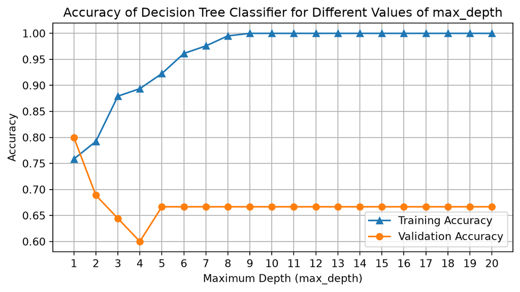

Why is the shape of the decision tree the way it is? What does this tell you about `max_depth` as a hyperparameter and its affect on the model’s ability generalise?

**Callout-answer**Answer**

```
explore_max_depth.py
```

```python
def explore_max_depth(X_train, y_train, X_val, y_val, max_depth_limit):
    """
    Explore the accuracy of the Decision Tree Classifier for different values of max_depth.

    Parameters
    ----------
    X_train : pd.DataFrame
        Training features.
    y_train : pd.Series
        Training labels.
    X_val : pd.DataFrame
        validation features.
    y_val : pd.Series
        validation labels.
    max_depth_limit : int
        The maximum depth to evaluate.

    Returns
    -------
    None
        Displays a plot of the training and validation accuracies of the
        Decision Tree Classifier for values of max_depth from 1 to
        max_depth_limit.
    """
    accuracies_train = []
    accuracies_val = []
    for depth in range(1, max_depth_limit + 1):
        decision_tree_classifier, accuracy_train, accuracy_val = train_decision_tree_classifier(X_train, y_train, X_val, y_val, depth)
        accuracies_train.append(accuracy_train)
        accuracies_val.append(accuracy_val)

    fig, ax = plt.subplots(figsize=(7, 4))
    ax.plot(range(1, max_depth_limit + 1), accuracies_train, marker='^',label='Training Accuracy')
    ax.plot(range(1, max_depth_limit + 1), accuracies_val, marker='o',label='validation Accuracy')
    ax.set_title('Accuracy of Decision Tree Classifier for Different Values of max_depth')
    ax.set_xlabel('Maximum Depth (max_depth)')
    ax.set_ylabel('Accuracy')
    ax.set_xticks(range(1, max_depth_limit + 1))
    ax.legend(loc='best')
    plt.grid()
    plt.tight_layout()
    plt.show()

max_depth_limit = 20
explore_max_depth(X_train, y_train, X_val, y_val, max_depth_limit)
```

Output

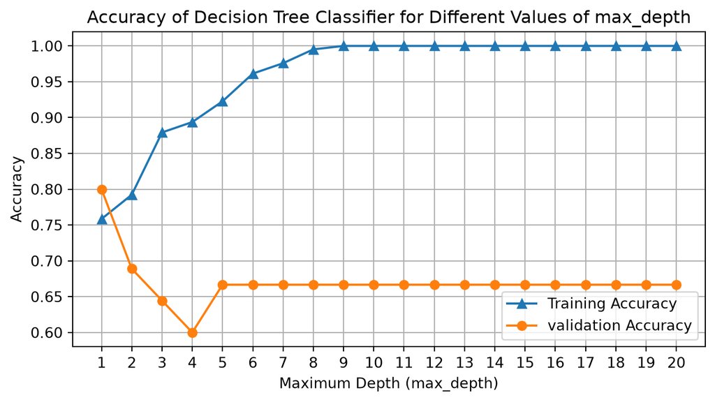

The shape of the accuracy curves highlights the role of the `max_depth` hyperparameter in controlling the complexity of a decision tree. As `max_depth` increases, the tree is allowed to make more splits and capture increasingly detailed patterns in the training data. This is reflected in the training accuracy, which steadily increases and eventually reaches 100%, indicating that the model is able to fit the training data almost perfectly.

However, the validation accuracy follows a different trend. The highest validation accuracy is achieved when `max_depth = 1`, after which the performance generally decreases and then remains relatively stable. This suggests that deeper trees are learning patterns that are specific to the training set rather than general trends that apply to unseen data. In other words, the model begins to **overfit** as the tree becomes more complex.

The growing gap between the training and validation accuracies provides clear evidence of overfitting. While deeper trees are able to achieve near-perfect performance on the training data, this additional complexity does not translate into improved performance on unseen observations. For this dataset, a tree with a `max_depth = 1` provides the best balance between model simplicity and predictive performance, and making it the preferred choice for the final model.

### Task 9 : Test the Decision Tree Classifier

Having selected the optimal value of `max_depth` using the validation set, we can now evaluate the final decision tree model on the testing set. Unlike the validation set, which is used for model selection and hyperparameter tuning, the testing set is reserved exclusively for the final assessment of model performance.

Using the optimal value of `max_depth` identified from the validation set, reuse the `train_decision_tree_classifier` function to train a decision tree classifier on the training data. Then evaluate the classifier on both the training and testing sets. Report the training and testing accuracies, and compare the results to assess whether the model generalises well to unseen data

```python
# Reuse the train_decision_tree_classifier function with the optimal value of max_depth
max_depth = max_depth_opt
decision_tree_classifier, accuracy_train, accuracy_test = train_decision_tree_classifier(X_train, y_train, X_test, y_test, max_depth)
print(f"Training accuracy of Decision Tree Classifier with max_depth={max_depth}: {accuracy_train:.2f}")
print(f"Testing accuracy of Decision Tree Classifier with max_depth={max_depth}: {accuracy_test:.2f}")
```

### Task 10 : Train a Random Forest Classifier

Now, let’s train a Random Forest Classifier, which is an ensemble (i.e. many sub-models whose output is combined) learning method that combines multiple decision trees to improve the model’s performance and reduce overfitting. The Random Forest Classifier works by creating multiple decision trees on different subsets of the dataset (a process called bagging) and taking the mode of their predictions to make a final prediction.

Write a function `train_random_forest_classifier` that takes the training features and labels as input and trains a Random Forest Classifier using `RandomForestClassifier` from `sklearn`. The hyperparameter to be explored today is `n_estimators`, which determines the number of trees in the forest. The function should then evaluate the accuracy of the model on both training and validation sets and return the trained classifier. Additionally, the random state of the model should be set to 42 for reproducibility.

```
train_random_forest_classifier.py
```

```python
def train_random_forest_classifier(X_train, y_train, X_val, y_val, n_estimators):
    """
    Train a Random Forest Classifier using the training features and labels.

    Parameters
    ----------
    X_train : pd.DataFrame
        Training features.
    y_train : pd.Series
        Training labels.
    n_estimators : int
        The number of trees in the forest.

    Returns
    -------
    random_forest_classifier : RandomForestClassifier
        The trained Random Forest Classifier.
    """

    return random_forest_classifier, accuracy_train, accuracy_val
```

The example usage of the function is provided below:

n_estimators = 20

random_forest_classifier, accuracy_train, accuracy_val = train_random_forest_classifier(X_train, y_train, X_val, y_val, n_estimators)

print(f"Training accuracy of Random Forest Classifier with n_estimators={n_estimators}: {accuracy_train:.2f}")

Training accuracy of Random Forest Classifier with n_estimators=20: 1.00

print(f"Validation accuracy of Random Forest Classifier with n_estimators={n_estimators}: {accuracy_val:.2f}")

Validation accuracy of Random Forest Classifier with n_estimators=20: 0.82

**Callout-answer**Answer**

```
train_random_forest_classifier.py
```

```python
def train_random_forest_classifier(X_train, y_train, X_val, y_val, n_estimators):
    """
    Train a Random Forest Classifier using the training features and labels.

    Parameters
    ----------
    X_train : pd.DataFrame
        Training features.
    y_train : pd.Series
        Training labels.
    n_estimators : int
        The number of trees in the forest.

    Returns
    -------
    random_forest_classifier : RandomForestClassifier
        The trained Random Forest Classifier.
    """
    # Create a Random Forest Classifier with the specified number of trees
    random_forest_classifier = RandomForestClassifier(n_estimators=n_estimators, random_state=42)

    # Train the Random Forest Classifier on the training data
    random_forest_classifier.fit(X_train, y_train)

    # Evaluate the accuracy of the model on the training set
    accuracy_train = random_forest_classifier.score(X_train, y_train)

    # Evaluate the accuracy of the model on the validation set
    accuracy_val = random_forest_classifier.score(X_val, y_val)

    return random_forest_classifier, accuracy_train, accuracy_val

n_estimators = 20
random_forest_classifier, accuracy_train, accuracy_val = train_random_forest_classifier(X_train, y_train, X_val, y_val, n_estimators)
print(f"Training accuracy of Random Forest Classifier with n_estimators={n_estimators}: {accuracy_train:.2f}")
print(f"Validation accuracy of Random Forest Classifier with n_estimators={n_estimators}: {accuracy_val:.2f}")
```

Output

```
Training accuracy of Random Forest Classifier with n_estimators=20: 1.00
Validation accuracy of Random Forest Classifier with n_estimators=20: 0.82
```

### Task 11 : Evaluate Different Values of `n_estimators`

Now that we have trained a Random Forest Classifier, we can evaluate the accuracy of the model for different values of `n_estimators`. Write a function `explore_n_estimators` that takes the training and validation features and labels as input, and evaluates the accuracy of the Random Forest Classifier for different values of `n_estimators` up to `max_estimators`.

```
explore_n_estimators.py
```

```python
def explore_n_estimators(X_train, y_train, X_val, y_val, max_estimators):
    """
    Explore the accuracy of the Random Forest Classifier for different values of n_estimators.

    Parameters
    ----------
    X_train : pd.DataFrame
        Training features.
    y_train : pd.Series
        Training labels.
    X_val : pd.DataFrame
        Validation features.
    y_val : pd.Series
        Validation labels.
    max_estimators : int
        The maximum number of estimators to evaluate.

    Returns
    -------
    None
        Displays a plot of the training and validation accuracies of the
        Random Forest Classifier for values of n_estimators from 1 to
        max_estimators.
    """
```

The function should show a plot of the accuracy against the number of estimators.

max_estimators = 30

explore_n_estimators(X_train, y_train, X_val, y_val, max_estimators)

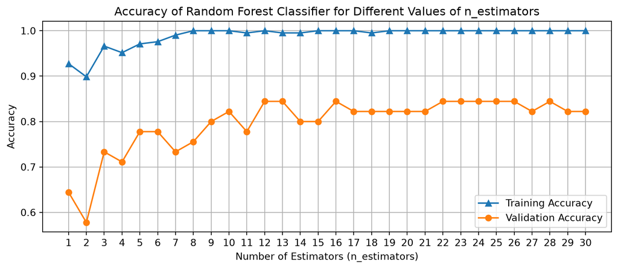

- What is the optimal value of `n_estimators` that yields the highest accuracy? Why might this be the case?
- Which model (Decision Tree, k-NN, and Random Forest) achieved the highest validation accuracy? Why might this be the case?

**Callout-answer**Answer**

```
explore_n_estimators.py
```

```python
def explore_n_estimators(X_train, y_train, X_val, y_val, max_estimators):
    """
    Explore the accuracy of the Random Forest Classifier for different values of n_estimators.

    Parameters
    ----------
    X_train : pd.DataFrame
        Training features.
    y_train : pd.Series
        Training labels.
    X_val : pd.DataFrame
        Validation features.
    y_val : pd.Series
        Validation labels.
    max_estimators : int
        The maximum number of estimators to evaluate.

    Returns
    -------
    None
        Displays a plot of the training and validation accuracies of the
        Random Forest Classifier for values of n_estimators from 1 to
        max_estimators.
    """

    accuracies_train = []
    accuracies_val = []
    for n in range(1, max_estimators + 1):
        random_forest_classifier, accuracy_train, accuracy_val = train_random_forest_classifier(X_train, y_train, X_val, y_val, n)
        accuracies_train.append(accuracy_train)
        accuracies_val.append(accuracy_val)

    fig, ax = plt.subplots(figsize=(9, 4))
    ax.plot(range(1, max_estimators + 1), accuracies_train, marker='^',label='Training Accuracy')
    ax.plot(range(1, max_estimators + 1), accuracies_val, marker='o',label='Validation Accuracy')
    ax.set_title('Accuracy of Random Forest Classifier for Different Values of n_estimators')
    ax.set_xlabel('Number of Estimators (n_estimators)')
    ax.set_ylabel('Accuracy')
    ax.set_xticks(range(1, max_estimators + 1))
    ax.legend(loc='best')
    plt.grid()
    plt.tight_layout()
    plt.show()

max_estimators = 30
explore_n_estimators(X_train, y_train, X_val, y_val, max_estimators)
```

Output

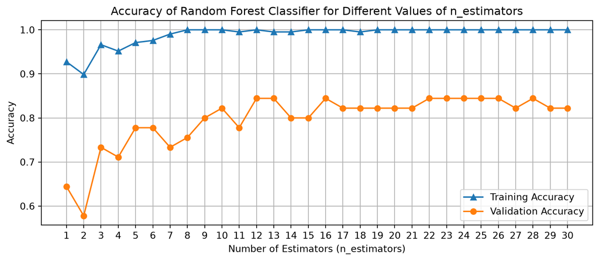

The validation accuracy generally increases as the number of estimators (`n_estimators`) increases before eventually reaching a plateau. The highest validation accuracy of approximately **84%** is achieved for several values of `n_estimators`. Since multiple values produce essentially the same maximum accuracy, it is generally preferable to select the smallest value that achieves this performance in order to minimise computational cost. Therefore, the optimal value of `n_estimators` is **12**, as it is the smallest number of trees that achieves the highest observed validation accuracy, and making it the preferred choice for the final model.

This behaviour is expected because a Random Forest is an **ensemble learning method** that combines the predictions of many decision trees. As the number of trees increases, the model becomes more stable and less sensitive to the specific training data used to construct individual trees. Consequently, the variance of the model decreases, often leading to improved generalisation performance on unseen data.

The training accuracy approaches 100% as the number of estimators increases, while the validation accuracy stabilises at around 84%. This suggests that the Random Forest is able to fit the training data extremely well while still maintaining strong predictive performance on unseen data. Unlike a single decision tree, the ensemble nature of the Random Forest helps reduce overfitting by averaging the predictions of many independently constructed trees.

### Task 12 : Test the Random Forest Classifier

Having selected the optimal value of `n_estimators` using the validation set, we can now evaluate the final Random Forest model on the testing set. Unlike the validation set, which is used for model selection and hyperparameter tuning, the testing set is reserved exclusively for the final assessment of model performance.

Using the optimal value of `n_estimators` identified from the validation set, reuse the `train_random_forest_classifier` function to train a Random Forest classifier on the training data. Then evaluate the classifier on both the training and testing sets. Report the training and testing accuracies, and compare the results to assess whether the model generalises well to unseen data.

```python
# Reuse the train_random_forest_classifier function with the optimal value of n_estimators
n_estimators = n_estimators_opt
random_forest_classifier, accuracy_train, accuracy_test = train_random_forest_classifier(X_train, y_train, X_test, y_test, n_estimators)
print(f"Training accuracy of Random Forest Classifier with n_estimators={n_estimators}: {accuracy_train:.2f}")
print(f"Testing accuracy of Random Forest Classifier with n_estimators={n_estimators}: {accuracy_test:.2f}")
```

## Conclusion

By the end of this tutorial, you should have a good appreciation of the k-NN, Decision Tree, and Random Forest machine learning models. Although we used them as classifiers, they can also be used for regression tasks. You should also have a good understanding of how to preprocess data, train models, and evaluate their performance using **accuracy** as a **classification metric**. Finally, you should have a good understanding of how to tune hyperparameters to improve model performance.

It is important to recognise that **accuracy is only one metric used to evaluate a classifier**. While accuracy provides a simple measure of the proportion of correct predictions, it does not distinguish between different types of classification errors. In many real-world applications, particularly those involving healthcare, process safety, or risk assessment, the consequences of different errors may not be equally important.

For this reason, data scientists and engineers often use additional performance metrics such as **precision**, **recall**, **F1-score**, **false negative (FN) rate**, and **false positive (FP) rate** to evaluate classification models more comprehensively. These metrics provide deeper insight into model behaviour and can help identify strengths and weaknesses that may not be apparent from accuracy alone.

In the next tutorial, you will learn how these metrics are calculated and interpreted, and how they can be used to make more informed assessments of classification model performance.

## Sources

- [Scikit-learn documentation](https://scikit-learn.org/stable/documentation.html)
- [K-Nearest Neighbors](https://scikit-learn.org/stable/modules/neighbors.html)
- [Decision Trees](https://scikit-learn.org/stable/modules/tree.html)
- [Random Forests](https://scikit-learn.org/stable/modules/ensemble.html#random-forests)